# Análise de Vendas - Produtos de Petróleo - ANP

Predictive Model

Felipe Daiha Alves

2022-11-28

# 1 **Disclaimer**:

Relatório da etapa de *machine lerarning* contendo informações e resultados sobre o processo de **Previsão de Vendas** de produtos derivados de petróleo.

# 2 **Objetivo**:

# 3 **Pipeline**:

## 3.1 . **Configuração de Ambiente**:

Etapa inicial do processo de modelagem. Nele, iremos configurar nosso ambiente de desenvolvimento e carregar a base de dados previamente tratada.

1. **Configurando Ambiente**  
   (Instalando e/ou carregando pacotes necessários e ajuste de opções de visualização.)

```r
# Nome dos pacotes

packages <- c(
  'rgl', ## Configuracao em RMarkdown
  'data.table', 'arrow',  ## Leitura de dados
  'dplyr', 'tidyr', 'zoo', 'lubridate', 'purrr', ## Manipulacao de Dados
  'prophet', ## Modelo de Series Temporais
  'ggplot2', 'gridExtra', 'scales', 'kableExtra', ## Visualizacao de Dados
  'MLmetrics' ## Avaliacao de resultados
  )


# Instalando pacotes (caso ainda nao esteja)

installed_packages <- packages %in% rownames(installed.packages())
if (any(installed_packages == FALSE)) {
  install.packages(packages[!installed_packages])
}


# Carregando pacotes

invisible(lapply(packages, library, character.only = TRUE))


# Removendo variaveis criadas previamente

rm(packages, installed_packages)


# Configuracoes de visualizacao no markdown

base::options(rgl.useNULL = TRUE, digits = 10, scipen = 999, encoding = "utf-8", dplyr.summarise.inform = FALSE)
rgl::setupKnitr(autoprint = TRUE)
```

2. **Carregando Dados**  
   (Carregamento de arquivo *.parquet* e print do arquivo para retomada de sua estrutura.)

```r
# Load da base de dados

sales_vbbr <- arrow::read_parquet(
  'C:/Users/daiha/OneDrive/Documentos/R/PS/Vibra/aux_datasets/cleaned_sales.parquet')


# Visualizacao primaria dos dados

dplyr::glimpse(sales_vbbr)
```

```
## Rows: 5,669
## Columns: 8
## $ grande_regiao                 <chr> "CO", "CO", "CO", "CO", "NE", "NE", "NE"…
## $ unidade_da_federacao          <chr> "DF", "GO", "MT", "MS", "AL", "BA", "CE"…
## $ year_mon                      <date> 2004-05-01, 2004-05-01, 2004-05-01, 200…
## $ media_valor_de_venda_ETANOL   <dbl> 1.3028967495, 1.0965353824, 1.3427362637…
## $ media_valor_de_venda_GASOLINA <dbl> 2.034324427, 2.005137955, 2.338270479, 2…
## $ volume_vendas_varejo_bcb      <dbl> 60.39, 47.73, 60.68, 43.94, 37.29, 48.14…
## $ vendas_etanol_hidratado       <dbl> 6225.922, 15017.495, 5158.432, 5901.304,…
## $ vendas_gasolina_c             <dbl> 57218.569, 69996.023, 29303.178, 26522.6…
```

- **Dicionário de Variáveis**
  - *grande_regiao* <> Região da Venda
  - *unidade_da_federacao* <> Estado da Venda
  - *year_mon* <> Ano-Mês da Venda
  - *media_valor_de_venda_ETANOL* <> Preço médio de venda de Etanol Hidratado nos postos
  - *media_valor_de_venda_GASOLINA* <> Preço médio de venda de Gasolina Comum nos postos
  - *volume_vendas_varejo_bcb* <> Indicador do volume de vendas totais no varejo
  - *vendas_etanol_hidratado* <> Volume total (m³) de vendas de Etanol Hidratado
  - *vendas_etanol_hidratado* <> Volume Total (m³) de vendas de Gasolina Comum

## 3.2 . **Avaliação do Problema**:

A finalidade dessa etapa é entender o comportamento ao longo do tempo das **Vendas de Gasolina C na Região Sudeste**. A view do dataframe está ajustada no momento para o agrupamento >>*year_mon, unidade_da_federacao, grande_regiao*<<

1. **Time Series Vendas Gasolina C**  
   (Construindo gráfico de Séries Temporais para analisar o comportamento das vendas à medida do tempo na Região Sudeste)

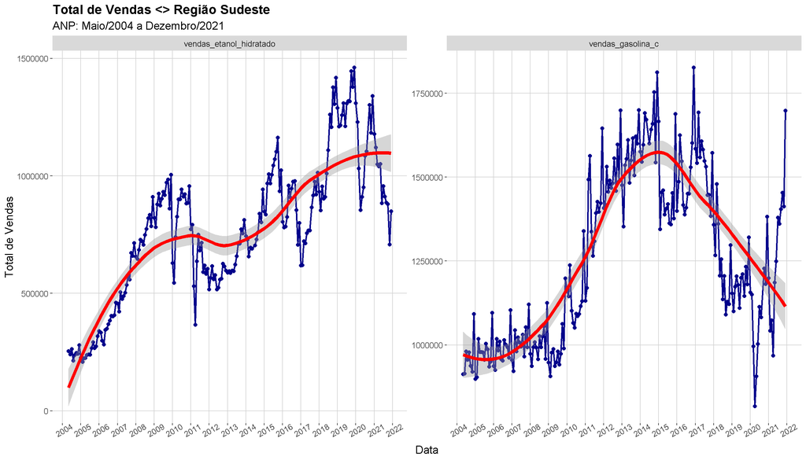

```r
# Filtrando apenas para regiao Sudeste e anos fechados

sales_vbbr <- sales_vbbr %>%
  dplyr::filter(grande_regiao == "SE")

# Plot para visualizacao

total_sales_product(sales_vbbr, "Região Sudeste")
```

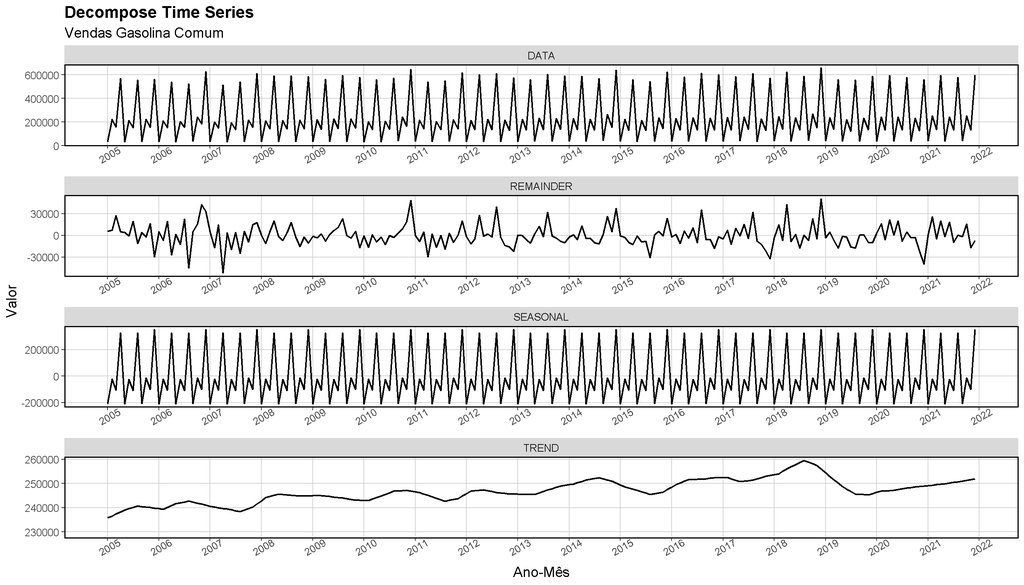

```r
# Decompose TS dataframe:

ts_gasolina <- decompose_ts_product(sales_vbbr$vendas_gasolina_c)

# Decompose TS plot:

decompose_plot(ts = ts_gasolina, sub = "Vendas Gasolina Comum")
```

```r
# Removendo time series

rm(ts_gasolina)

# Dataframe sumarizado

sales_vbbr <- sales_vbbr %>%
  dplyr::select(!c(grande_regiao, unidade_da_federacao)) %>%
  dplyr::group_by(year_mon) %>%
  dplyr::summarise(
    dplyr::across(
      !dplyr::starts_with("vendas"),
      ~mean(.x, na.rm = TRUE),
      .names = "avg_{.col}"
    ),
    dplyr::across(
      dplyr::starts_with("vendas"),
      ~sum(.x, na.rm = TRUE),
      .names = "sum_{.col}"
    )
  )
```

**Comments:** Para a visão sumarizada da Região Sudeste, foi capturada a **soma** das vendas de **Etanol Hidratado** e **Gasolina Comum**. Já para o caso do **preço** de revenda nos postos e o volume de **vendas no varejo**, foi considerara a média dos estados que compõem a região do país.

## 3.3 . **Modelando Séries Temporais & Avaliação de Resultados**:

Posteriormente, inicia-se o processo de previsão de séries temporais construindo modelos de *machine learning* apropriados para tal finalidade. Para o problema, utilizaremos o algoritmo *Prophet*, extremamente utilizado para séries temporais com: (a) **efeitos sazonais fortes**; (b) **grande histórico de dados**, (c) **alterações de tendência** e (d) **presença de outliers** (TAYLOR; LETHAM, 2017)

1. **Utilizando Médias Móveis como Valor dos Regressores**  
   (Puxando dados de média móvel dos últimos meses para estimar regressores no passado)

```r
# Calculo de medias moveis com 3 meses de referencia

sales_vbbr <- sales_vbbr %>%
  dplyr::mutate(
    dplyr::across(c(dplyr::starts_with("avg"), "sum_vendas_etanol_hidratado"),
      ~zoo::rollmean(.x, k = 3, fill = NA, align = "right"),
      .names = "movAvg_{.col}"
    )
  ) %>%
  dplyr::select(year_mon, dplyr::starts_with("movAvg"), sum_vendas_gasolina_c) %>%
  tidyr::drop_na()

# Print na tela

glimpse(sales_vbbr)
```

```
## Rows: 208
## Columns: 6
## $ year_mon                                 <date> 2004-07-01, 2004-08-01, 2004…
## $ movAvg_avg_media_valor_de_venda_ETANOL   <dbl> 1.095214003, 1.158863029, 1.2…
## $ movAvg_avg_media_valor_de_venda_GASOLINA <dbl> 2.024885064, 2.066936796, 2.0…
## $ movAvg_avg_volume_vendas_varejo_bcb      <dbl> 52.17083333, 51.87333333, 51.…
## $ movAvg_sum_vendas_etanol_hidratado       <dbl> 252974.0173, 239694.5320, 238…
## $ sum_vendas_gasolina_c                    <dbl> 980556.821, 955775.952, 97842…
```

2. **Construindo Modelo com Prophet**  
   (Adicionando parâmetros ao modelo, ajustando regressores e fitando modelo com dataset de treino)

```r
# Criando copia do db e renomeando colunas conforme necessidade no Prophet

train_sales <- sales_vbbr %>%
  dplyr::rename(
    ds = year_mon,
    y = sum_vendas_gasolina_c)

# Ajuste de parametros primarios verificados no processo de decomposicao

model_prophet <- prophet::prophet(
  growth = "linear",
  yearly.seasonality = TRUE,
  weekly.seasonality = FALSE,
  daily.seasonality = FALSE,
  seasonality.mode = 'additive')

# Passando regressores para o modelo

model_prophet <- regressors_2_prophet(
  model_prophet,
  c("movAvg_avg_media_valor_de_venda_ETANOL",
    "movAvg_avg_media_valor_de_venda_GASOLINA",
    "movAvg_avg_volume_vendas_varejo_bcb",
    "movAvg_sum_vendas_etanol_hidratado"))

# Fitando modelo com o dataframe de treino

model_prophet <- prophet::fit.prophet(
  model_prophet, train_sales)
```

(Aplicando validacao cruzada e extraindo resultados da base de treino)

```r
# Start time para calculo

startTime = Sys.time()

# Extraindo resultados de train set

train_results <- prophet::cross_validation(
  model = model_prophet,
  horizon = 90,
  initial = 365.25,
  units = "days"
)

# Pegando o fim da execução do codigo

endTime <- Sys.time()

# Calulando o tempo de duracao em

paste0("CV execution time: ", round(as.vector(difftime(endTime, startTime, units='mins')), 1), " minutes.")
```

```
## [1] "CV execution time: 8.8 minutes."
```

```r
# Dropando variaveis indesejadas

rm(endTime, startTime)
```

```r
# Visualizacao de MAE e RMSE

tbl_view(
  metrics_prophet(train_results),
  "Métricas de Avaliação - Treino por Janela de Tempo")
```

**Métricas de Avaliação - Treino por Janela de Tempo**

|  | horizon | rmse | mae | mape |
| --- | --- | --- | --- | --- |
| 1 | 30 | 266327.1530 | 104167.8280 | 0.0935286227 |
| 2 | 60 | 271832.4393 | 104819.2912 | 0.0945868962 |
| 3 | 90 | 471578.4637 | 143996.3717 | 0.1375943361 |

**Comments:** Aqui, aplica-se o método de validação cruzada do tipo *rolling CV*, no qual é utilizado para treino um conjunto de **1 ano** (conforme a sazonalidade) para previsão dos próximos **3 meses** (conforme o problema proposto). O objetivo é obter o menor valor de **MAPE** para a previsão.  
As métricas variaram conforme o horizonte de tempo, mantendo as métricas de erro menores no prazo de **1 e 2 meses** do que em relação aos prazo de **3 meses**.

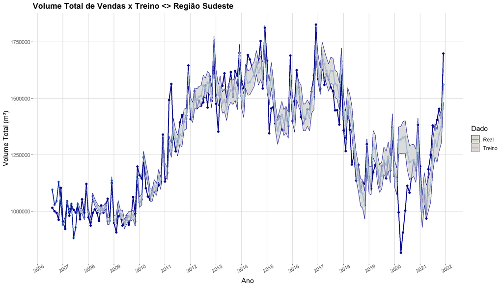

```r
# Metricas de avaliacao dos dados de treino (Considerar previsao de teste na CV apenas horizonte * 1)

metrics_df_train <- train_results %>%
    dplyr::filter(ds >= min(as.Date(train_results$ds)) + lubridate::years(1)) %>%
    dplyr::group_by(ds) %>%
    dplyr::summarise(
      dplyr::across(
        dplyr::starts_with("y"),
        ~mean(.x, na.rm = TRUE),
        .names = "train_{.col}"
      )
    )

real_prediction_plot(metrics_df_train, ds, train_y, train_yhat, "Treino", train_yhat_lower, train_yhat_upper)
```

**Comments:** O modelo aparentemente tem dificuldade de capturar fortes períodos de **volatilidade** nas vendas totais. Como o histórico de dados não apresenta essa característica tão explícita, o processo de validação cruzada não captura esses mudanças abruptas e o erro é maior nesses períodos. Fica evidente por exemplo no período de pandemia no mundo durante a COVID-19. O volume de vendas cai abruptamente e o modelo não consegue capturar esse tipo de informação. Porém, a informação é rapidamente absorvida e a nova tendência já é considerada para previsões futuras.

## 3.4 . **Forecasting de Dados Futuros**:

Por fim, buscamos a resposta para o problema proposto. Iremos prever os valores de vendas de gasolina comum na Região Sudeste para os 3 primeiros meses de 2022 e para o ano completo.

1. **Construindo dataframe**  
   (Criando dados futuros para previsao de vendas)

```r
# Previsao de regressores

future_regressors <- predict_regressors()
```

```
## [1] "Regressor >movAvg_avg_media_valor_de_venda_ETANOL< previsto!"
## [1] "Regressor >movAvg_avg_media_valor_de_venda_GASOLINA< previsto!"
## [1] "Regressor >movAvg_avg_volume_vendas_varejo_bcb< previsto!"
## [1] "Regressor >movAvg_sum_vendas_etanol_hidratado< previsto!"
```

```r
# Previsao de dados futuros (proximos 12 meses)

df_predict <- predict(
  model_prophet, future_regressors) %>%
  dplyr::select(ds, yhat_lower, yhat, yhat_upper)

# Mostrando dataframe

head(df_predict, 12)
```

```
##            ds   yhat_lower        yhat  yhat_upper
## 1  2022-01-01 1040277.5627 1115834.771 1196369.240
## 2  2022-02-01  979146.7923 1058313.060 1135026.706
## 3  2022-03-01 1079413.8285 1155133.957 1228841.776
## 4  2022-04-01 1045073.4804 1120677.669 1205492.714
## 5  2022-05-01 1011224.3309 1089620.980 1166385.398
## 6  2022-06-01  977028.9914 1059288.295 1136496.247
## 7  2022-07-01 1012889.3477 1087517.201 1161610.891
## 8  2022-08-01 1031450.1629 1109465.460 1183346.756
## 9  2022-09-01 1005716.4811 1085189.908 1160961.582
## 10 2022-10-01 1057035.8142 1130805.541 1206891.946
## 11 2022-11-01 1001412.9447 1078950.234 1156924.544
## 12 2022-12-01 1189033.5596 1265717.010 1346380.847
```

**Comments:** Para previsão dos valores das features para os próximos 12 meses, foi utilizado o próprio *Prophet* para cada variável, sem inclusão de regressores nos sub-modelos para a obtenção dos dados.

2. **Plotando visualizacao**  
   (Grafico dados reais e previsão futura)

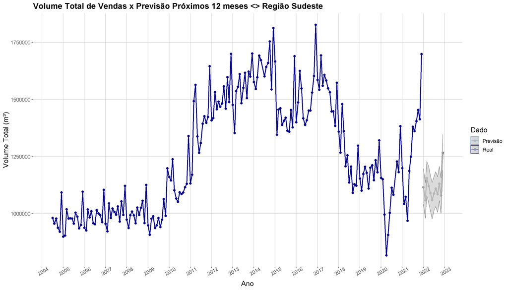

```r
# Visualizacao das previsoes para os proximos 12 meses

ggplot2::ggplot(
  data = dplyr::bind_rows(
  df_predict %>% dplyr::mutate(ds = as.Date(ds), dataset = "Prediction"),
  sales_vbbr %>% dplyr::select(ds = year_mon, yhat = sum_vendas_gasolina_c) %>% dplyr::mutate(dataset = "Real")),
  aes(x = as.Date(ds), y = yhat, colour = dataset)) +
  ggplot2::geom_line(linetype = "solid", size = 1) +
  ggplot2::geom_point(size = 2) +
  ggplot2::scale_x_date(breaks = "1 year", date_labels = "%Y") +
  ggplot2::scale_colour_manual(
    name = "Dado",
    limits = c("Previsão", "Real"),
    values = c("#4892D2", "darkblue")) +
  ggplot2::geom_ribbon(aes(ymin = yhat_lower, ymax = yhat_upper), fill = "grey80", alpha=0.7) +
  ggplot2::labs(
    title = paste0("Volume Total de Vendas x Previsão Próximos 12 meses <> Região Sudeste"),
    x = 'Ano',
    y = 'Volume Total (m³)') +
  ggplot2::theme(
    panel.background = element_rect(fill = "white"),
    legend.title = element_text(size = 14.0),
    legend.text = element_text(size = 10.0),
    axis.text.x = element_text(angle = 30, size = 10.0),
    axis.text.y = element_text(size = 10.0),
    axis.title.x = element_text(size = 14.0),
    axis.title.y = element_text(size = 14.0),
    panel.grid.major.y =  element_line(colour = "lightgrey"),
    panel.grid.major.x =  element_line(colour = "lightgrey"),
    plot.title = element_text(size = 16.0, face = "bold"),
    plot.subtitle = element_text(size = 14.0),
    strip.text.x = element_text(size = 10.0))
```

3. **Volume de Vendas - Região Sudeste**  
   (Solução do problema proposto em visão sumarizada)

```r
tbl_view(
    data.frame(
      proximos_3_meses = sum(df_predict$yhat[df_predict$ds <= "2022-03-01"], na.rm = TRUE),
      proximos_12_meses = sum(df_predict$yhat, na.rm = TRUE)
    ),
    "Previsão de Vendas <> Gasolina Comum (m³) na Região Sudeste")
```

**Previsão de Vendas <> Gasolina Comum (m³) na Região Sudeste**

|  | proximos_3_meses | proximos_12_meses |
| --- | --- | --- |
| 1 | 3329281.788 | 13356514.09 |

## 3.5 . **Sugestões Futuras**:

Devido ao prazo e a complexidade do problema, há de fato muito espaço para melhorias. Os principais pontos a serem otimizados são:

- **Melhorias**
  - *1 - Maior nº de regressores* <> Foram capturadas e estudadas variáveis a serem utilizadas como regressores de forma rápida e objetiva em fontes públicas e consultado junto à colegas especialistas da área. Pode-se **explorar novas features** capazes de auxiliarem o processo de previsão
  - *2 - Médias Móveis conforme CV* <> A metodologia aplicada para retomar ao cenário no passado e considerar as informações da época foi utilizar médias móveis das variáveis. Entretanto, é mais fidedigno o processo ser encaixado dentro da **rolling CV**. Ou ainda usar o próprio *Prophet* dentro do processo de validação cruzada para prever o valor dos regressores a medida que o CV vai rearranjando os conjuntos de treino e teste na sua metodologia.
  - *3 - Prever Gasolina Comum por Fórmula* <> Há inúmeros fatores que afetam o preço e as vendas deste produto: Fatores políticos; econômicos; crises; etc. Uma alternativa para chegar na mesma previsão seria prever as vendas de Gasolina Comum *“por tabela”*, ao prever a venda total do conjunto **Gasolina + Etanol** e buscar mais parâmetros que impactem na venda geral de combustíveis (e.g. Circulação de Carros nas Ruas; Crédito para Financiamentos Veiculares; etc.).
  - *4 - Criação de Modelos para Horizontes de Tempos* <> Outro ponto de melhoria considerável seria elaborar modelos para previsão de **curto/médio/longo prazo**. A ideia de usar um único estimador para a previsão da série temporal não é errada, mas os resultados serão mais otimizados e com menor erro se houver uma **divisão conforme o horizonte de tempo** que se quer prever, assim como é feito para a previsão por região/estado/produto.